# Full infer Pipeline Examples

## Confidence intervals

### One numerical (one mean)

Finding the observed statistic,

```r
x_bar <- gss %>%
  specify(response = hours) %>%
  calculate(stat = "mean")
```

Alternatively, using the `observe()` wrapper to calculate the observed statistic,

```r
x_bar <- gss %>%
  observe(response = hours, stat = "mean")
```

Then, generating a bootstrap distribution,

```r
boot_dist <- gss %>%
   specify(response = hours) %>%
   generate(reps = 1000, type = "bootstrap") %>%
   calculate(stat = "mean")
```

Use the bootstrap distribution to find a confidence interval,

```r
percentile_ci <- get_ci(boot_dist)
```

Visualizing the observed statistic alongside the distribution,

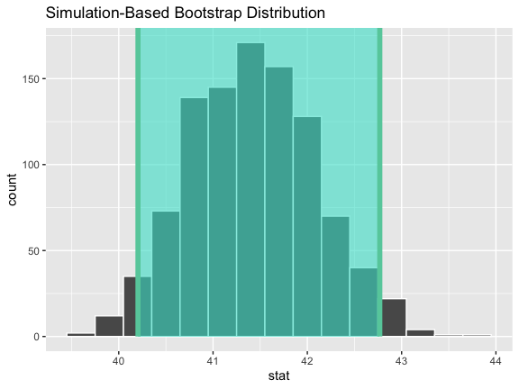

```r
visualize(boot_dist) +
  shade_confidence_interval(endpoints = percentile_ci)
```

Alternatively, use the bootstrap distribution to find a confidence interval using the standard error,

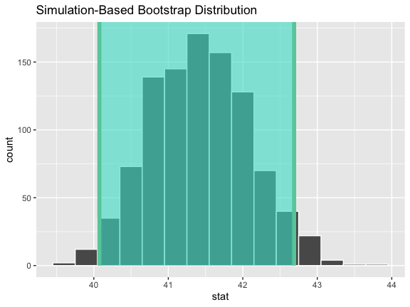

```r
standard_error_ci <- get_ci(boot_dist, type = "se", point_estimate = x_bar)

visualize(boot_dist) +
  shade_confidence_interval(endpoints = standard_error_ci)
```

Instead of a simulation-based bootstrap distribution, we can also define a theory-based sampling distribution,

```r
sampling_dist <- gss %>%
   specify(response = hours) %>%
   assume(distribution = "t")
```

Visualization and calculation of confidence intervals interfaces in the same way as with the simulation-based distribution,

```r
theor_ci <- get_ci(sampling_dist, point_estimate = x_bar)

theor_ci
```

| lower_ci | upper_ci |
| --- | --- |
| 40.08 | 42.68 |

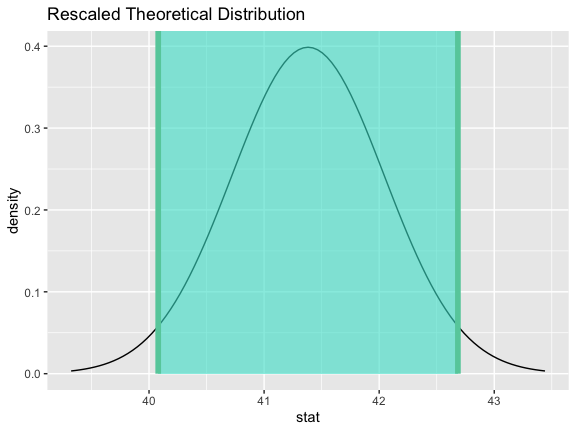

```r
visualize(sampling_dist) +
  shade_confidence_interval(endpoints = theor_ci)
```

Note that the `t` distribution is recentered and rescaled to lie on the scale of the observed data. `infer` does not support confidence intervals on means via the `z` distribution.

### One numerical (one mean - standardized)

Finding the observed statistic,

```r
t_hat <- gss %>%
  specify(response = hours) %>%
  hypothesize(null = "point", mu = 40) %>%
  calculate(stat = "t")
```

Alternatively, using the `observe()` wrapper to calculate the observed statistic,

```r
t_hat <- gss %>%
  observe(response = hours,
          null = "point", mu = 40,
          stat = "t")
```

Then, generating the bootstrap distribution,

```r
boot_dist <- gss %>%
   specify(response = hours) %>%
   generate(reps = 1000, type = "bootstrap") %>%
   calculate(stat = "t")
```

Use the bootstrap distribution to find a confidence interval,

```r
percentile_ci <- get_ci(boot_dist)
```

Visualizing the observed statistic alongside the distribution,

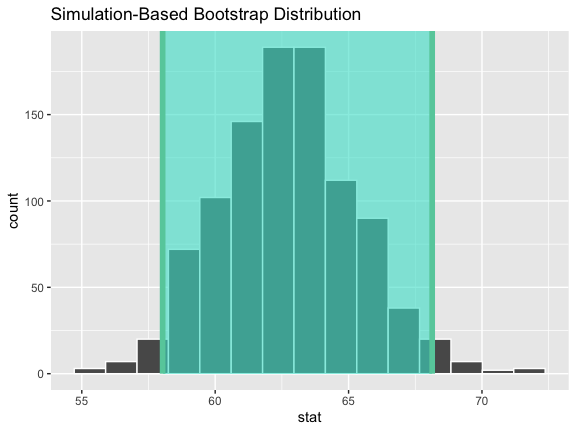

```r
visualize(boot_dist) +
  shade_confidence_interval(endpoints = percentile_ci)
```

Alternatively, use the bootstrap distribution to find a confidence interval using the standard error,

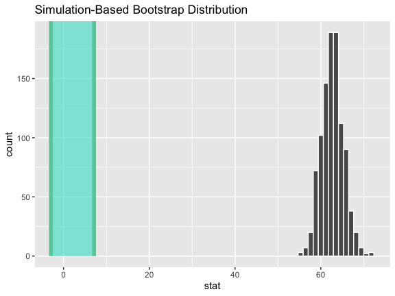

```r
standard_error_ci <- boot_dist %>%
  get_ci(type = "se", point_estimate = t_hat)

visualize(boot_dist) +
  shade_confidence_interval(endpoints = standard_error_ci)
```

See the above subsection (one mean) for a theory-based approach. Note that `infer` does not support confidence intervals on means via the `z` distribution.

### One categorical (one proportion)

Finding the observed statistic,

```r
p_hat <- gss %>%
   specify(response = sex, success = "female") %>%
   calculate(stat = "prop")
```

Alternatively, using the `observe()` wrapper to calculate the observed statistic,

```r
p_hat <- gss %>%
   observe(response = sex, success = "female", stat = "prop")
```

Then, generating a bootstrap distribution,

```r
boot_dist <- gss %>%
 specify(response = sex, success = "female") %>%
 generate(reps = 1000, type = "bootstrap") %>%
 calculate(stat = "prop")
```

Use the bootstrap distribution to find a confidence interval,

```r
percentile_ci <- get_ci(boot_dist)
```

Visualizing the observed statistic alongside the distribution,

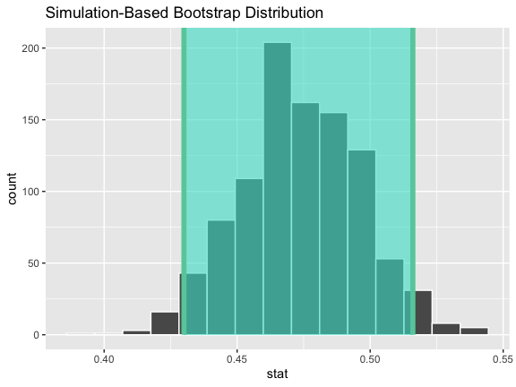

```r
visualize(boot_dist) +
  shade_confidence_interval(endpoints = percentile_ci)
```

Alternatively, use the bootstrap distribution to find a confidence interval using the standard error,

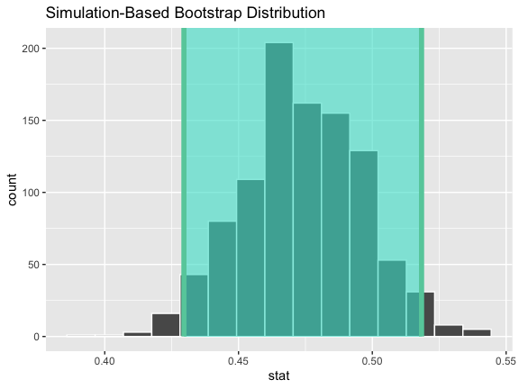

```r
standard_error_ci <- boot_dist %>%
  get_ci(type = "se", point_estimate = p_hat)

visualize(boot_dist) +
  shade_confidence_interval(endpoints = standard_error_ci)
```

Instead of a simulation-based bootstrap distribution, we can also define a theory-based sampling distribution,

```r
sampling_dist <- gss %>%
   specify(response = sex, success = "female") %>%
   assume(distribution = "z")
```

Visualization and calculation of confidence intervals interfaces in the same way as with the simulation-based distribution,

```r
theor_ci <- get_ci(sampling_dist, point_estimate = p_hat)

theor_ci
```

| lower_ci | upper_ci |
| --- | --- |
| 0.4302 | 0.5178 |

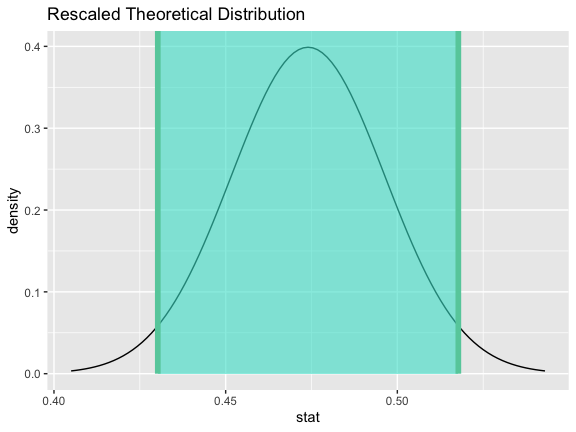

```r
visualize(sampling_dist) +
  shade_confidence_interval(endpoints = theor_ci)
```

Note that the `z` distribution is recentered and rescaled to lie on the scale of the observed data. `infer` does not support confidence intervals on means via the `z` distribution.

### One categorical variable (standardized proportion $z$)

See the above subsection (one proportion) for a theory-based approach.

### One numerical variable, one categorical (2 levels) (diff in means)

Finding the observed statistic,

```r
d_hat <- gss %>%
  specify(hours ~ college) %>%
  calculate(stat = "diff in means", order = c("degree", "no degree"))
```

Alternatively, using the `observe()` wrapper to calculate the observed statistic,

```r
d_hat <- gss %>%
  observe(hours ~ college,
          stat = "diff in means", order = c("degree", "no degree"))
```

Then, generating a bootstrap distribution,

```r
boot_dist <- gss %>%
   specify(hours ~ college) %>%
   generate(reps = 1000, type = "bootstrap") %>%
   calculate(stat = "diff in means", order = c("degree", "no degree"))
```

Use the bootstrap distribution to find a confidence interval,

```r
percentile_ci <- get_ci(boot_dist)
```

Visualizing the observed statistic alongside the distribution,

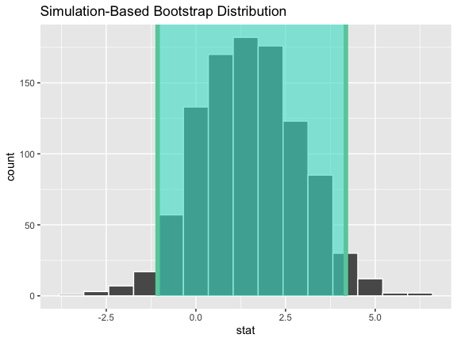

```r
visualize(boot_dist) +
  shade_confidence_interval(endpoints = percentile_ci)
```

Alternatively, use the bootstrap distribution to find a confidence interval using the standard error,

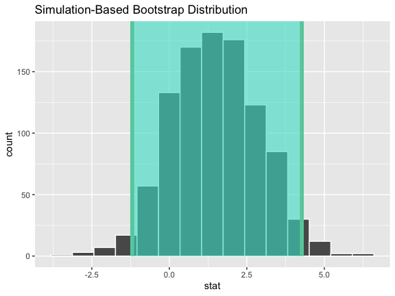

```r
standard_error_ci <- boot_dist %>%
  get_ci(type = "se", point_estimate = d_hat)

visualize(boot_dist) +
  shade_confidence_interval(endpoints = standard_error_ci)
```

Instead of a simulation-based bootstrap distribution, we can also define a theory-based sampling distribution,

```r
sampling_dist <- gss %>%
   specify(hours ~ college) %>%
   assume(distribution = "t")
```

Visualization and calculation of confidence intervals interfaces in the same way as with the simulation-based distribution,

```r
theor_ci <- get_ci(sampling_dist, point_estimate = d_hat)

theor_ci
```

| lower_ci | upper_ci |
| --- | --- |
| -1.164 | 4.241 |

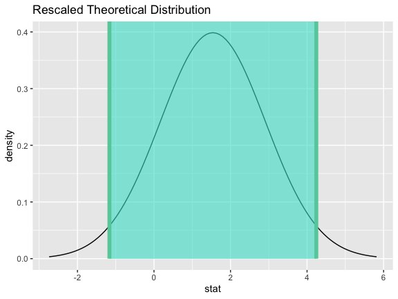

```r
visualize(sampling_dist) +
  shade_confidence_interval(endpoints = theor_ci)
```

Note that the `t` distribution is recentered and rescaled to lie on the scale of the observed data.

`infer` also provides functionality to calculate ratios of means. The workflow looks similar to that for `diff in means`.

Finding the observed statistic,

```r
d_hat <- gss %>%
  specify(hours ~ college) %>%
  calculate(stat = "ratio of means", order = c("degree", "no degree"))
```

Alternatively, using the `observe()` wrapper to calculate the observed statistic,

```r
d_hat <- gss %>%
  observe(hours ~ college,
          stat = "ratio of means", order = c("degree", "no degree"))
```

Then, generating a bootstrap distribution,

```r
boot_dist <- gss %>%
   specify(hours ~ college) %>%
   generate(reps = 1000, type = "bootstrap") %>%
   calculate(stat = "ratio of means", order = c("degree", "no degree"))
```

Use the bootstrap distribution to find a confidence interval,

```r
percentile_ci <- get_ci(boot_dist)
```

Visualizing the observed statistic alongside the distribution,

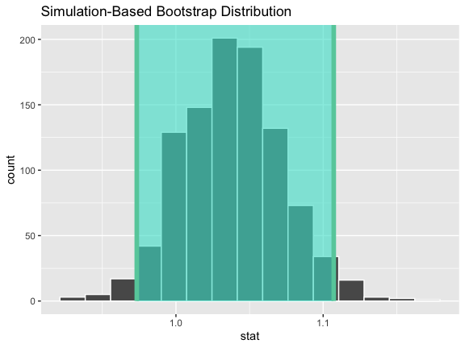

```r
visualize(boot_dist) +
  shade_confidence_interval(endpoints = percentile_ci)
```

Alternatively, use the bootstrap distribution to find a confidence interval using the standard error,

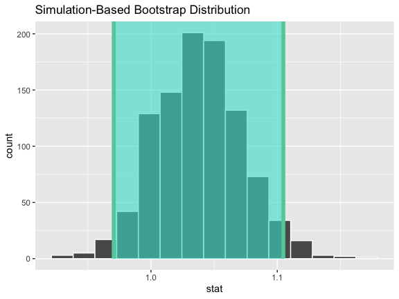

```r
standard_error_ci <- boot_dist %>%
  get_ci(type = "se", point_estimate = d_hat)

visualize(boot_dist) +
  shade_confidence_interval(endpoints = standard_error_ci)
```

### One numerical variable, one categorical (2 levels) (t)

Finding the standardized point estimate,

```r
t_hat <- gss %>%
  specify(hours ~ college) %>%
  calculate(stat = "t", order = c("degree", "no degree"))
```

Alternatively, using the `observe()` wrapper to calculate the observed statistic,

```r
t_hat <- gss %>%
  observe(hours ~ college,
          stat = "t", order = c("degree", "no degree"))
```

Then, generating a bootstrap distribution,

```r
boot_dist <- gss %>%
   specify(hours ~ college) %>%
   generate(reps = 1000, type = "bootstrap") %>%
   calculate(stat = "t", order = c("degree", "no degree"))
```

Use the bootstrap distribution to find a confidence interval,

```r
percentile_ci <- get_ci(boot_dist)
```

Visualizing the observed statistic alongside the distribution,

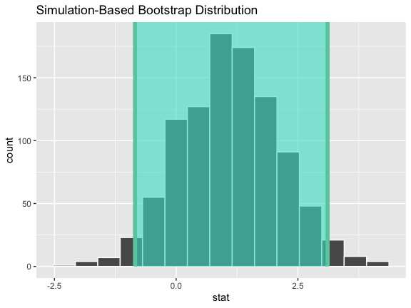

```r
visualize(boot_dist) +
  shade_confidence_interval(endpoints = percentile_ci)
```

Alternatively, use the bootstrap distribution to find a confidence interval using the standard error,

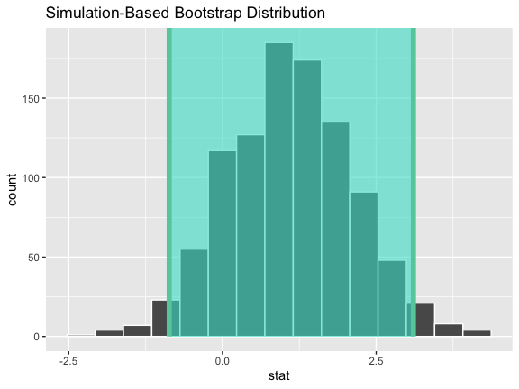

```r
standard_error_ci <- boot_dist %>%
  get_ci(type = "se", point_estimate = t_hat)

visualize(boot_dist) +
  shade_confidence_interval(endpoints = standard_error_ci)
```

See the above subsection (diff in means) for a theory-based approach. `infer` does not support confidence intervals on means via the `z` distribution.

### Two categorical variables (diff in proportions)

Finding the observed statistic,

```r
d_hat <- gss %>%
  specify(college ~ sex, success = "degree") %>%
  calculate(stat = "diff in props", order = c("female", "male"))
```

Alternatively, using the `observe()` wrapper to calculate the observed statistic,

```r
d_hat <- gss %>%
  observe(college ~ sex, success = "degree",
          stat = "diff in props", order = c("female", "male"))
```

Then, generating a bootstrap distribution,

```r
boot_dist <- gss %>%
  specify(college ~ sex, success = "degree") %>%
  generate(reps = 1000, type = "bootstrap") %>%
  calculate(stat = "diff in props", order = c("female", "male"))
```

Use the bootstrap distribution to find a confidence interval,

```r
percentile_ci <- get_ci(boot_dist)
```

Visualizing the observed statistic alongside the distribution,

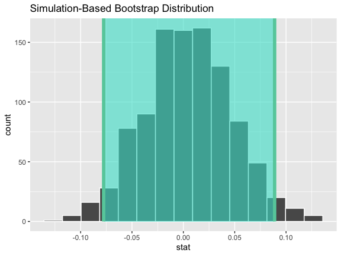

```r
visualize(boot_dist) +
  shade_confidence_interval(endpoints = percentile_ci)
```

Alternatively, use the bootstrap distribution to find a confidence interval using the standard error,

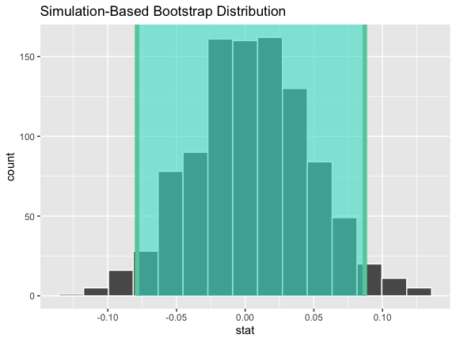

```r
standard_error_ci <- boot_dist %>%
  get_ci(type = "se", point_estimate = d_hat)

visualize(boot_dist) +
  shade_confidence_interval(endpoints = standard_error_ci)
```

Instead of a simulation-based bootstrap distribution, we can also define a theory-based sampling distribution,

```r
sampling_dist <- gss %>%
  specify(college ~ sex, success = "degree") %>%
   assume(distribution = "z")
```

Visualization and calculation of confidence intervals interfaces in the same way as with the simulation-based distribution,

```r
theor_ci <- get_ci(sampling_dist, point_estimate = d_hat)

theor_ci
```

| lower_ci | upper_ci |
| --- | --- |
| -0.0794 | 0.0878 |

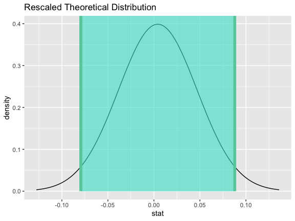

```r
visualize(sampling_dist) +
  shade_confidence_interval(endpoints = theor_ci)
```

Note that the `z` distribution is recentered and rescaled to lie on the scale of the observed data.

### Two categorical variables (z)

Finding the standardized point estimate,

```r
z_hat <- gss %>%
  specify(college ~ sex, success = "degree") %>%
  calculate(stat = "z", order = c("female", "male"))
```

Alternatively, using the `observe()` wrapper to calculate the observed statistic,

```r
z_hat <- gss %>%
  observe(college ~ sex, success = "degree",
          stat = "z", order = c("female", "male"))
```

Then, generating a bootstrap distribution,

```r
boot_dist <- gss %>%
  specify(college ~ sex, success = "degree") %>%
  generate(reps = 1000, type = "bootstrap") %>%
  calculate(stat = "z", order = c("female", "male"))
```

Use the bootstrap distribution to find a confidence interval,

```r
percentile_ci <- get_ci(boot_dist)
```

Visualizing the observed statistic alongside the distribution,

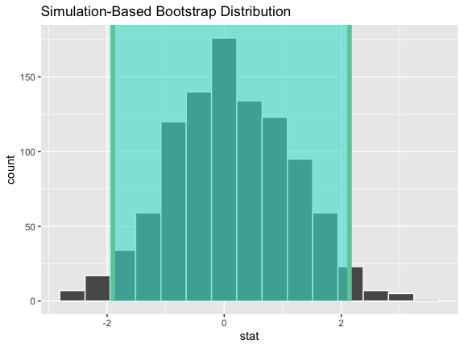

```r
visualize(boot_dist) +
  shade_confidence_interval(endpoints = percentile_ci)
```

Alternatively, use the bootstrap distribution to find a confidence interval using the standard error,

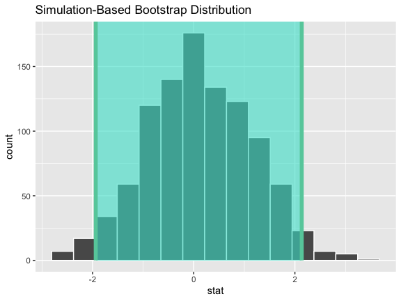

```r
standard_error_ci <- boot_dist %>%
  get_ci(type = "se", point_estimate = z_hat)

visualize(boot_dist) +
  shade_confidence_interval(endpoints = standard_error_ci)
```

See the above subsection (diff in props) for a theory-based approach.

### Two numerical vars - SLR

Finding the observed statistic,

```r
slope_hat <- gss %>%
  specify(hours ~ age) %>%
  calculate(stat = "slope")
```

Alternatively, using the `observe()` wrapper to calculate the observed statistic,

```r
slope_hat <- gss %>%
  observe(hours ~ age, stat = "slope")
```

Then, generating a bootstrap distribution,

```r
boot_dist <- gss %>%
   specify(hours ~ age) %>%
   generate(reps = 1000, type = "bootstrap") %>%
   calculate(stat = "slope")
```

Use the bootstrap distribution to find a confidence interval,

```r
percentile_ci <- get_ci(boot_dist)
```

Visualizing the observed statistic alongside the distribution,

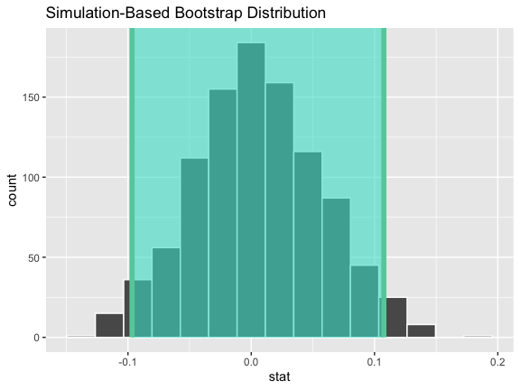

```r
visualize(boot_dist) +
  shade_confidence_interval(endpoints = percentile_ci)
```

Alternatively, use the bootstrap distribution to find a confidence interval using the standard error,

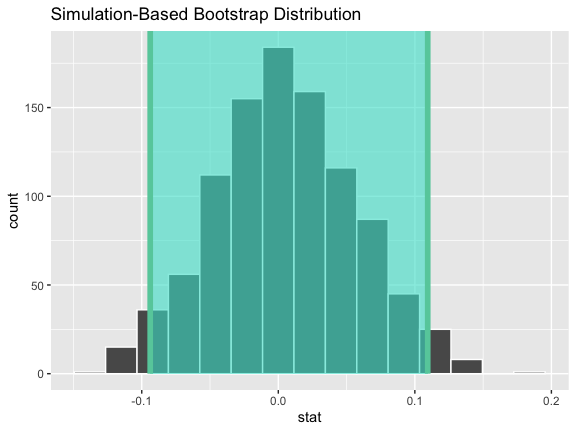

```r
standard_error_ci <- boot_dist %>%
  get_ci(type = "se", point_estimate = slope_hat)

visualize(boot_dist) +
  shade_confidence_interval(endpoints = standard_error_ci)
```

### Two numerical vars - correlation

Finding the observed statistic,

```r
correlation_hat <- gss %>%
  specify(hours ~ age) %>%
  calculate(stat = "correlation")
```

Alternatively, using the `observe()` wrapper to calculate the observed statistic,

```r
correlation_hat <- gss %>%
  observe(hours ~ age, stat = "correlation")
```

Then, generating a bootstrap distribution,

```r
boot_dist <- gss %>%
   specify(hours ~ age) %>%
   generate(reps = 1000, type = "bootstrap") %>%
   calculate(stat = "correlation")
```

Use the bootstrap distribution to find a confidence interval,

```r
percentile_ci <- get_ci(boot_dist)
```

Visualizing the observed statistic alongside the distribution,

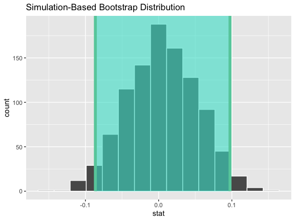

```r
visualize(boot_dist) +
  shade_confidence_interval(endpoints = percentile_ci)
```

Alternatively, use the bootstrap distribution to find a confidence interval using the standard error,

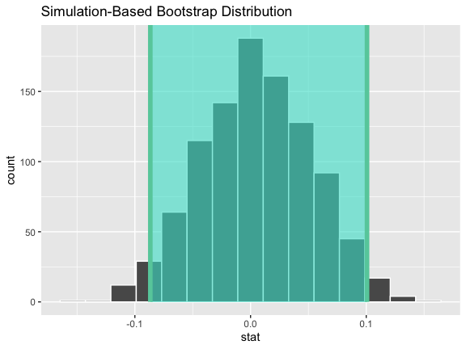

```r
standard_error_ci <- boot_dist %>%
  get_ci(type = "se", point_estimate = correlation_hat)

visualize(boot_dist) +
  shade_confidence_interval(endpoints = standard_error_ci)
```

### Two numerical vars - t

Not currently implemented since $t$ could refer to standardized slope or standardized correlation.

### Multiple explanatory variables

Calculating the observed fit,

```r
obs_fit <- gss %>%
  specify(hours ~ age + college) %>%
  fit()
```

Then, generating a bootstrap distribution,

```r
boot_dist <- gss %>%
  specify(hours ~ age + college) %>%
  generate(reps = 1000, type = "bootstrap") %>%
  fit()
```

Use the bootstrap distribution to find a confidence interval,

```r
conf_ints <-
  get_confidence_interval(
    boot_dist,
    level = .95,
    point_estimate = obs_fit
  )
```

Visualizing the observed statistic alongside the distribution,

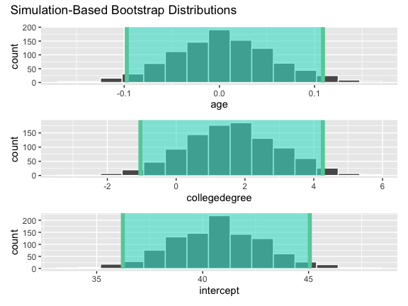

```r
visualize(boot_dist) +
  shade_confidence_interval(endpoints = conf_ints)
```

Note that this `fit()`-based workflow can be applied to use cases with differing numbers of explanatory variables and explanatory variable types.